# Moneyball: An analysis of the relation between expenditures and success in Major League Baseball

Author: Pranav Rane

### Import packages

```python
import sqlite3
import pandas
from matplotlib import pyplot as plt
import math
import numpy as np
```

### Load data and extract using SQL

```python
# connect to database
sqlite_file = 'lahman2014.sqlite'
conn = sqlite3.connect(sqlite_file)
```

```python
# try querying
salary_query = "SELECT yearID, sum(salary) as total_payroll FROM Salaries WHERE lgID == 'AL' GROUP BY yearID"
team_salaries = pandas.read_sql(salary_query,conn)
team_salaries.head()
```

|  | yearID | total_payroll |
| --- | --- | --- |
| 0 | 1985 | 134401120.0 |
| 1 | 1986 | 157716444.0 |
| 2 | 1987 | 136088747.0 |
| 3 | 1988 | 157049812.0 |
| 4 | 1989 | 188771688.0 |

```python
# use relational database to query data...use inner join
query = """
SELECT
    t.teamID,
    t.yearID,
    SUM(s.salary) AS totalSalary,
    t.W,
    t.L,
    t.W*100/162.0 AS winPercentage,
    t.Rank,
    t.G
FROM
    Teams t
JOIN Salaries s
    ON t.teamID==s.teamID AND t.yearID==s.yearID
GROUP BY
    t.teamID,t.yearID
"""
data = pandas.read_sql(query,conn)
```

```python
data
```

|  | teamID | yearID | totalSalary | W | L | winPercentage | Rank | G |
| --- | --- | --- | --- | --- | --- | --- | --- | --- |
| 0 | ANA | 1997 | 31135472.0 | 84 | 78 | 51.851852 | 2 | 162 |
| 1 | ANA | 1998 | 41281000.0 | 85 | 77 | 52.469136 | 2 | 162 |
| 2 | ANA | 1999 | 55388166.0 | 70 | 92 | 43.209877 | 4 | 162 |
| 3 | ANA | 2000 | 51464167.0 | 82 | 80 | 50.617284 | 3 | 162 |
| 4 | ANA | 2001 | 47535167.0 | 75 | 87 | 46.296296 | 3 | 162 |
| ... | ... | ... | ... | ... | ... | ... | ... | ... |
| 853 | WAS | 2010 | 61400000.0 | 69 | 93 | 42.592593 | 5 | 162 |
| 854 | WAS | 2011 | 63856928.0 | 80 | 81 | 49.382716 | 3 | 161 |
| 855 | WAS | 2012 | 80855143.0 | 98 | 64 | 60.493827 | 1 | 162 |
| 856 | WAS | 2013 | 113703270.0 | 86 | 76 | 53.086420 | 2 | 162 |
| 857 | WAS | 2014 | 131983680.0 | 96 | 66 | 59.259259 | 1 | 162 |

858 rows × 8 columns

The SQL query selects certain columns from the "teams" and "salaries" tables and performs an inner join to match up the teamIDs and the yearIDs. We utilize SUM and other operations to calculate win percentage and total salaries. The resulting table is stored in "data" as a Pandas dataframe. There will be missing data in the relation since there is no salary information in early years of baseball. Thus, the joined dataset will not include teams from early years. Since our main goal is to analyze the salaries of various teams and their win percentages, there is no point including the teams without salaries.

### Visualize Team Expenditure

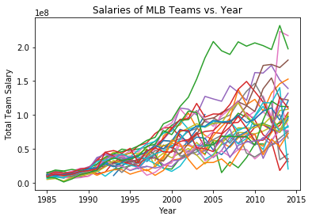

```python
# Now plot payroll vs years for each team
# find unqiue team ids
teamIDs = data['teamID'].unique()
dataLength = data.shape[0]
numOfTeams = len(teamIDs)
for i in range(numOfTeams):
    yData = []
    xData = []
    teamName = teamIDs[i]
    for j in range(dataLength):
        if (data.iat[j,0]==teamName):
            xData.append(data.iat[j,1])
            yData.append(data.iat[j,2])
    plt.plot(xData,yData,label=teamName)
plt.title("Salaries of MLB Teams vs. Year")
plt.xlabel("Year")
plt.ylabel("Total Team Salary")
```

The figure contains 30 line plots that correspond to team payroll on a given year. Based on the plot, I can state that team salary appears to generally increase as time goes on. Additionally, the spread of salaries has increased over time. However, this plot does not give any information on the relationship between increased spending and win percentage.

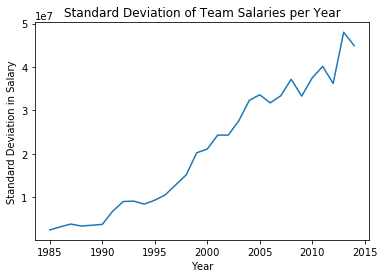

```python
# Show the standard deviation of the payroll over time to confirm the increase in spread
years = data['yearID'].unique()
numOfYears = len(years)
sx = np.zeros(numOfYears)
xbar = np.zeros(numOfYears)
for i in range(numOfYears):
    y = years[i]
    sData = []
    for j in range(dataLength):
        if (data.iat[j,1]==y):
            # elemts of sData contain the total salary for each team
            sData.append(data.iat[j,2])
    xbar[i] = sum(sData)/len(sData)
    l = len(sData)
    sx2 = 0
    for xi in sData:
        sx2 = sx2+(xi-xbar[i])**2
    sx[i] = math.sqrt(sx2/l)


sortedIdx = np.argsort(years)
plt.plot(years[sortedIdx],sx[sortedIdx],label='std')
plt.title("Standard Deviation of Team Salaries per Year")
plt.xlabel("Year")
plt.ylabel("Standard Deviation in Salary")
```

The figure confirms the increase in spread in expenditures by MLB teams each year. As mentioned before, it is easy to see that the spread of total salaries increases with the year.

### Visualize expenditure vs. winning percentage

To visualize this relation, we will split up the data into different 5 year time periods from 1989 to 2014.

```python
# Discretize into time periods, and plot each scatter plot
discreteData = pandas.DataFrame(data)
intervals = [(1989,1994),(1994,1999),(1999,2004),(2004,2009),(2009,2014)]
bins = pandas.IntervalIndex.from_tuples(intervals)
discreteData['yearGroup'] = pandas.cut(discreteData['yearID'],bins)
```

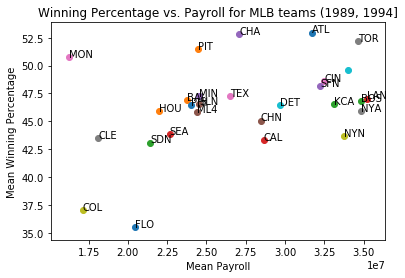

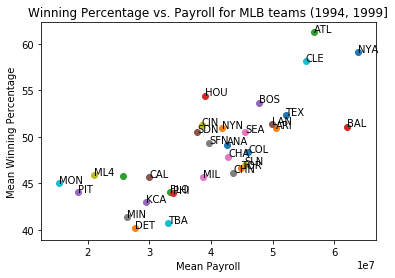

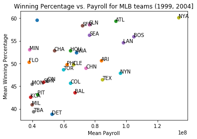

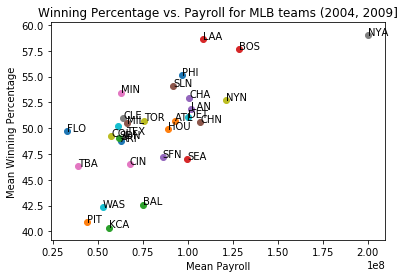

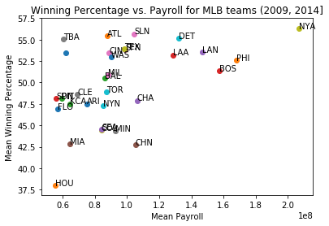

```python
# interval 1
for i in bins:
    plt.figure()
    for j in teamIDs:
        payroll = 0
        wp = 0
        num = 0
        for k in range(dataLength):
            if ((discreteData.iat[k,8]==i) and (discreteData.iat[k,0]==j)):
                payroll = payroll + discreteData.iat[k,2]
                wp = wp + discreteData.iat[k,5]
                num = num+1
        if num!=0:
            payroll = payroll/num
            wp = wp/num
            plt.scatter(payroll,wp)
            if j!="OAK":
                plt.text(payroll,wp,j)
    plt.title("Winning Percentage vs. Payroll for MLB teams %s"%str(i))
    plt.xlabel("Mean Payroll")
    plt.ylabel("Mean Winning Percentage")
```

We can see that in the earlier years of baseball, especially from 1995-1999, an increase in payroll spending from teams is correlated to a higher winning percentage. In 2000-2004, this correlation decreases a bit, only to increase in the 2005-2009 seasons. In 2010-2014 this correlation drops a bit again. However, the variance of the payrolls over the years makes it hard to make direct comparisions

The Oakland Athletics had an impressive seasons from 2000-2004 as the team had top winning percentages but was well below the average payroll compared to teams that had similar winning percentages. The New York Yankees have shown to continuously spend the most on player salaries and have kept at the top in terms of winning percentages over the years. The Boston Red Sox have also shown to pay for win percentages.